# Trabalho Computacional 4 - Testes de Hipóteses

Gustavo Almeida Silva

# Exemplo 1.1

Consideremos as medidas de um índice de placa bacteriana obtidas de 26 crianças em idade pré-escolar, antes e depois do uso de uma escova Convencional. Veja página 505 do livro. Vamos testar para o nível de significância de $5\%$, se os índices médios de placa bacteriana antes e depois da escovação são iguais.

```r
IndicesPlaca=readr::read_csv2('IndicesPlaca.csv',show_col_types = F)

head(IndicesPlaca) %>%
  kbl(caption = "") %>%
  kable_classic(full_width = F, html_font = "Cambria")
```

| Sujeito | Sexo | Antes_Hugger | Depois_Hugger | Antes_Convencional | Depois_Convencional |
| --- | --- | --- | --- | --- | --- |
| 1 | F | 2.18 | 0.43 | 1.20 | 0.75 |
| 2 | F | 2.05 | 0.08 | 1.43 | 0.55 |
| 3 | F | 1.05 | 0.18 | 0.68 | 0.08 |
| 4 | F | 1.95 | 0.78 | 1.45 | 0.75 |
| 5 | F | 0.28 | 0.03 | 0.50 | 0.05 |
| 6 | F | 2.63 | 0.23 | 2.75 | 1.60 |

## Resolução escrita

Neste exemplo, iremos testar a hipotese da diferença entre a media de duas amostras dependentes ser igual a 0. Para isso iremos utilizar o **Teste T-pareado**, Definiu-se as seguintes hipoteses.

- $H_0: \mu_{\text{antes}}=\mu_{\text{depois}}$
- $H_1: \mu_{\text{antes}}\neq\mu_{\text{depois}}$

Supondo a normalidade da população, iremos utilizar a seguinte estatistica de teste:

- $T=\frac{\bar{D}-\Delta_0}{S_d/\sqrt{n}}\sim t_{n-1}$, onde
  - $\Delta_0=0$, baseado na hipotese nula
  - $\bar{D}=\frac{\sum{D_i}}{n}$
  - $S_d^2=\frac{\sum({D_i-\bar{D}})^2}{n-1}$

Substituindo os valores amostrais, temos o seguinte valor para a estatistica de teste: $t=7.8127$

Para calcular o limite inferior e superior, queremos encontrar $\lambda_1$ e $\lambda_2$ que satisfaçam:

- $P(\lambda_1<T< \lambda_2)=0.95$

Utilizando a seguinte função:

```r
df=data.frame(lower=qt(0.025,df=25),
              upper=qt(0.975,df=25))
```

Temos o seguinte resultado:

```r
df %>%
  kbl(caption = "") %>%
  kable_classic(full_width = F, html_font = "Cambria")
```

| lower | upper |
| --- | --- |
| -2.059539 | 2.059539 |

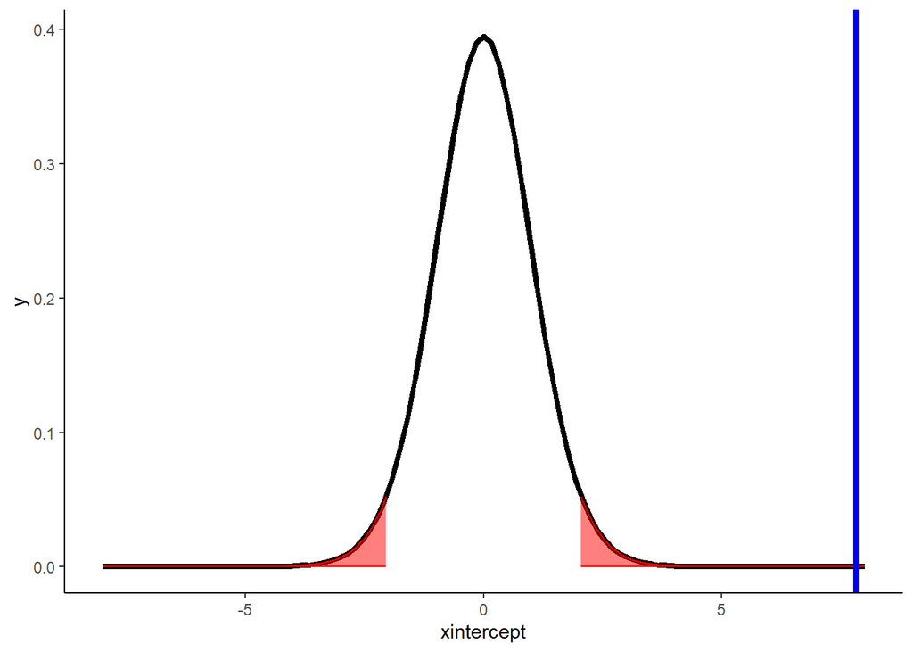

```r
base=ggplot() +
  xlim(-8, 8)

base +
  geom_function(fun = dt,args = list(df=25),linewidth=1.5)+
  stat_function(fun = dt,args = list(df=25), color = "red", fill = "red", geom = "area",xlim=c(-8, -2.05), alpha = 0.5)+
  stat_function(fun = dt,args = list(df=25), color = "red", fill = "red", geom = "area",xlim=c(2.05, 8), alpha = 0.5)+
  theme_classic()+
  geom_vline(xintercept = 7.8127,linewidth=1.5,col='blue')
```

Assim, é possivel ver que o intervalo não contem o valor da estatistica do teste: 7.8127 e portanto rejeita-se $H_0$, a diferença entre as medias de um índice de placa bacteriana obtidas de 26 crianças antes e depois da utilização de uma escova convencional não é $0$ com $5\%$ significancia

## Resolução computacional

```r
t.test(IndicesPlaca$Antes_Convencional,IndicesPlaca$Depois_Convencional,alternative = 'two.sided',paired=T,conf.level = .95)
```

```
##
##  Paired t-test
##
## data:  IndicesPlaca$Antes_Convencional and IndicesPlaca$Depois_Convencional
## t = 7.8127, df = 25, p-value = 3.609e-08
## alternative hypothesis: true difference in means is not equal to 0
## 95 percent confidence interval:
##  0.8290017 1.4225367
## sample estimates:
## mean of the differences
##                1.125769
```

# Exemplo 1.2

Consideremos as medidas de um índice de placa bacteriana obtidas de 26 crianças em idade pré-escolar, depois do uso de uma escova experimental (Hugger) e de uma escova Convencional. Veja página 505 do livro. Vamos testar para o nível de significância de $5\%$, se os índices médios de placa bacteriana depois da escovação diferem em relação à escova utilizada.

## Resolução escrita

Neste exemplo, iremos testar a hipotese da diferença entre a media de duas amostras dependentes ser igual a 0. Para isso iremos utilizar o **Teste T-pareado**, Definiu-se as seguintes hipoteses.

- $H_0: \mu_{\text{convencional}}=\mu_{\text{hugger}}$
- $H_1: \mu_{\text{antes}}\neq\mu_{\text{hugger}}$

Supondo a normalidade da população, iremos utilizar a seguinte estatistica de teste:

- $T=\frac{\bar{D}-\Delta_0}{S_d/\sqrt{n}}\sim t_{n-1}$, onde
  - $\Delta_0=0$, baseado na hipotese nula
  - $\bar{D}=\frac{\sum{D_i}}{n}$
  - $S_p=\frac{\sum({D_i-\bar{D}})^2}{n-1}$

Substituindo os valores amostrais, temos o seguinte valor para a estatistica de teste: $t=4.2579$

Para calcular o limite inferior e superior, queremos encontrar $\lambda_1$ e $\lambda_2$ que satisfaçam:

- $P(\lambda_1<T< \lambda_2)=0.95$

Utilizando a seguinte função:

```r
df=data.frame(lower=qt(0.025,df=25),
              upper=qt(0.975,df=25))
```

Temos o seguinte resultado:

```r
df %>%
  kbl(caption = "") %>%
  kable_classic(full_width = F, html_font = "Cambria")
```

| lower | upper |
| --- | --- |
| -2.059539 | 2.059539 |

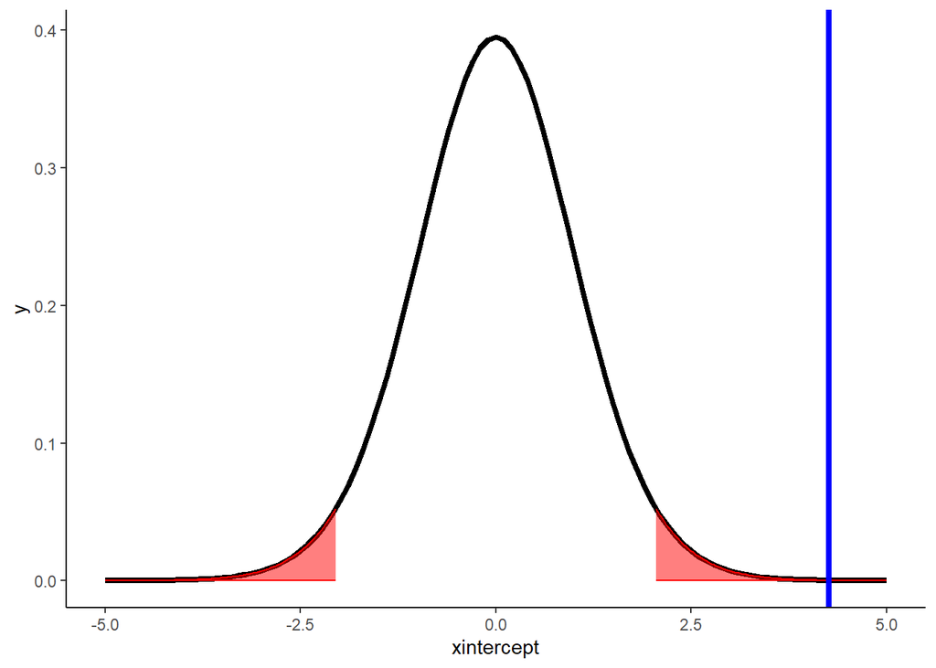

```r
base=ggplot() +
  xlim(-5, 5)

base +
  geom_function(fun = dt,args = list(df=25),linewidth=1.5)+
  stat_function(fun = dt,args = list(df=25), color = "red", fill = "red", geom = "area",xlim=c(-5, -2.05), alpha = 0.5)+
  stat_function(fun = dt,args = list(df=25), color = "red", fill = "red", geom = "area",xlim=c(2.05, 5), alpha = 0.5)+
  theme_classic()+
  geom_vline(xintercept = 4.25797,linewidth=1.5,col='blue')
```

Assim, é possivel ver que o intervalo não contem o valor da estatistica do teste: 4.2579 e portanto rejeita-se $H_0$, a diferença entre as medias de um índice de placa bacteriana obtidas de 26 crianças depois da utilização de uma escova Hugger e depois da utilização de uma escova convencional não é $0$ com $5\%$ significancia

## Resolução computacional

```r
t.test(IndicesPlaca$Depois_Convencional,IndicesPlaca$Depois_Hugger,alternative = 'two.sided',paired=T,conf.level = .95)
```

```
##
##  Paired t-test
##
## data:  IndicesPlaca$Depois_Convencional and IndicesPlaca$Depois_Hugger
## t = 4.2579, df = 25, p-value = 0.0002549
## alternative hypothesis: true difference in means is not equal to 0
## 95 percent confidence interval:
##  0.2559653 0.7355731
## sample estimates:
## mean of the differences
##               0.4957692
```

# Exemplo 2.1

Vamos avaliar se existem diferenças entre as notas dos alunos das turmas F e G, independente do gênero, com nível de significância de $5\%$.

```r
NotasProb=readr::read_csv('dados - Plan1.csv')%>%
                      rename(TurmaFGen=`Gênero - Turma  F`,TurmaFNotas=`Probabilidade - Turma F`,TurmaGGen=`Gênero - Turma  G`,TurmaGNotas=`Probabilidade - Turma G`)

NotasProb%>%
      head()%>%
      kbl(caption = "") %>%
      kable_classic(full_width = F, html_font = "Cambria")
```

| TurmaFGen | TurmaFNotas | TurmaGGen | TurmaGNotas |
| --- | --- | --- | --- |
| F | 61 | F | 60 |
| M | 21 | M | 56 |
| M | 84 | M | 71 |
| M | 89 | F | 66 |
| F | 66 | M | 60 |
| M | 22 | M | 69 |

## Resolução escrita

Neste exemplo, iremos testar a hipotese da diferença entre a media de duas amostras independentes ser igual a 0. Antes de realizarmos o teste para a media, precisamos identificar se as duas amostras possuem variancias iguais.

Assim, construindo o teste de hipotese para a variancia, com $5\%$ de significancia

$H_0:\frac{\sigma_1^2}{\sigma_2^2}=1$

$H_1:\frac{\sigma_1^2}{\sigma_2^2}\neq 1$

Utilizaremos a seguinte estística de teste: $F=\frac{S_1^1\sigma_2^2}{S_2^1\sigma_1^2}\sim F(m-1,n-1)$, onde $m$ é o tamanho amostral 1 e $n$ é o tamanho amostral 2

Substituindo os dados amostrais, temos o seguinte valor para a estatistica de teste

$$F=\frac{S_1^1\sigma_2^2}{S_2^1\sigma_1^2}=1.314338$$

Agora, devemos encontrar os valores quantilicos $\lambda_1$ e $\lambda_2$ da distribuição f(41,49) que satisfazem:

$$P(\lambda_1<F<\lambda_2)=0.95$$

```r
df=data.frame(lower=qf(0.025,df1 = 41,df2= 49),
              upper=qf(0.975,df1 = 41,df2= 49))
```

```r
df %>%
  kbl(caption = "") %>%
  kable_classic(full_width = F, html_font = "Cambria")
```

| lower | upper |
| --- | --- |
| 0.5476079 | 1.79741 |

Assim, é possivel notar que o valor da estatistica do teste está dentro desse intervalo e portanto não rejeita-se $H_0$, a razão de $sigma^2$ das 2 amostras é igual a $1$

Utilizando o resultado do teste anterior, iremos propor um teste de hipotese para media das 2 amostras, onde não rejeitou-se a hipotese delas possuirem variancia iguais

Temos as seguintes hipoteses:

- $H_0:\mu_{TurmaF}=\mu_{TurmaG}$
- $H_0:\mu_{TurmaF}\neq\mu_{TurmaG}$

Supondo a normalidade da população, iremos utilizar a seguinte estatistica de teste:

- $T=\frac{\bar{X_1}-\bar{X_2}-\Delta_0}{S_p(\sqrt{\frac{1}{n}-\frac{1}{m}})}\sim t_{v}$, onde
  - $v=n+m-2$
  - $\Delta_0=0$, baseado na hipotese nula
  - $S_p=\frac{(n-1)S_1^2+(m-1)S_2^2}{n+m-2}$

Dado um nivel de significancia de $5%$, queremos encontrar $\lambda_1$ e $\lambda_2$ que satisfaçam:

$$P(\lambda_1<t<\lambda_2)=0.95$$

```r
df=data.frame(lower=qt(0.025,df=90),
              upper=qt(0.975,df=90))
```

```r
df %>%
  kbl(caption = "") %>%
  kable_classic(full_width = F, html_font = "Cambria")
```

| lower | upper |
| --- | --- |
| -1.986674 | 1.986674 |

Calculando $S_p$ e o valor da estatistica do teste

$$S_p^2=\frac{(42-1)297.4593+(50-1)226.3188}{42+50-2}=258.7272$$
Logo $S_p=\sqrt{S_p^2}=16.085$

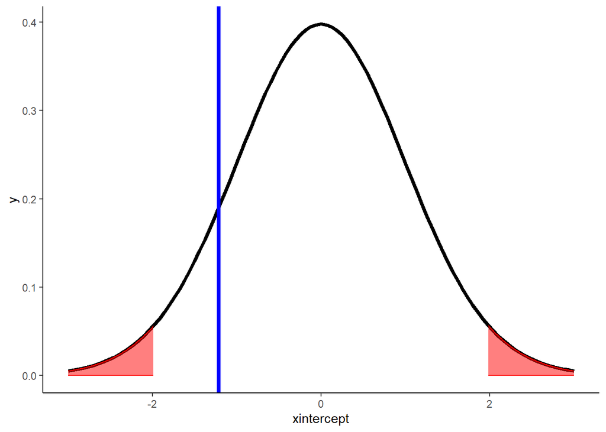

```r
base=ggplot() +
  xlim(-3, 3)

base +
  geom_function(fun = dt,args = list(df=90),linewidth=1.5)+
  stat_function(fun = dt,args = list(df=90), color = "red", fill = "red", geom = "area",xlim=c(-3, -1.986), alpha = 0.5)+
  stat_function(fun = dt,args = list(df=90), color = "red", fill = "red", geom = "area",xlim=c(1.986, 3), alpha = 0.5)+
  theme_classic()+
  geom_vline(xintercept = -1.212,linewidth=1.5,col='blue')
```

Assim, é possivel notar que o valor da estatistica do teste está dentro do intervalo calculado e portanto não rejeita-se $H_0$, a diferença entre as medias de 2 turmas de probabilidade é $0$ com $5\%$ significancia

## Resolução computacional

```r
var.test(NotasProb$TurmaFNotas, NotasProb$TurmaGNotas, ratio = 1,
         alternative = "two.sided",
         conf.level = 0.95)
```

```
##
##  F test to compare two variances
##
## data:  NotasProb$TurmaFNotas and NotasProb$TurmaGNotas
## F = 1.3143, num df = 41, denom df = 49, p-value = 0.358
## alternative hypothesis: true ratio of variances is not equal to 1
## 95 percent confidence interval:
##  0.731240 2.400144
## sample estimates:
## ratio of variances
##           1.314338
```

```r
t.test(NotasProb$TurmaFNotas[!is.na(NotasProb$TurmaFNotas)],NotasProb$TurmaGNotas,alternative = 'two.sided',paired=F,var.equal = T,conf.level = .95)
```

```
##
##  Two Sample t-test
##
## data:  NotasProb$TurmaFNotas[!is.na(NotasProb$TurmaFNotas)] and NotasProb$TurmaGNotas
## t = -1.2158, df = 90, p-value = 0.2272
## alternative hypothesis: true difference in means is not equal to 0
## 95 percent confidence interval:
##  -10.781885   2.595218
## sample estimates:
## mean of x mean of y
##  63.16667  67.26000
```

# Exemplo 2.2

Vamos avaliar se existem diferenças entre as notas dos alunos da turma G de acordo com o gênero. Há alguma evidência, ao nível de significância de $5\%$, que o desempenho das alunas é melhor que o dos alunos?

```r
notas_masc_turma_g=NotasProb%>%
                        select(TurmaGGen, TurmaGNotas)%>%
                        filter(TurmaGGen=='M')

notas_fem_turma_g=NotasProb%>%
                       select(TurmaGGen, TurmaGNotas)%>%
                       filter(TurmaGGen=='F')
```

```r
notas_fem_turma_g%>%
      head()%>%
      kbl(caption = "") %>%
      kable_classic(full_width = F, html_font = "Cambria")
```

| TurmaGGen | TurmaGNotas |
| --- | --- |
| F | 60 |
| F | 66 |
| F | 39 |
| F | 64 |
| F | 39 |
| F | 55 |

```r
notas_masc_turma_g%>%
      head()%>%
      kbl(caption = "") %>%
      kable_classic(full_width = F, html_font = "Cambria")
```

| TurmaGGen | TurmaGNotas |
| --- | --- |
| M | 56 |
| M | 71 |
| M | 60 |
| M | 69 |
| M | 53 |
| M | 78 |

## Resolução escrita

Neste exemplo, iremos testar a hipotese da diferença entre a media de duas amostras independentes ser igual a 0. Antes de realizarmos o teste para a media, precisamos identificar se as duas amostras possuem variancias iguais.

Assim, construindo o teste de hipotese para a variancia, com $5\%$ de significancia

$H_0:\frac{\sigma_{fem}^2}{\sigma_{masc}^2}=1$

$H_1:\frac{\sigma_{fem}^2}{\sigma_{masc}^2}\neq 1$

Utilizaremos a seguinte estística de teste: $F=\frac{S_{fem}^2\sigma_{masc}^2}{S_{masc}^2\sigma_{fem}^2}\sim F(m-1,n-1)$, onde $m$ é o tamanho amostral das notas femininas e $n$ é o tamanho amostral das notas masculinas

Substituindo os dados amostrais, temos o seguinte valor para a estatistica de teste

$$\frac{S_1^1\sigma_2^2}{S_2^1\sigma_1^2}=1.293574$$

Agora, devemos encontrar os valores quantilicos $\lambda_1$ e $\lambda_2$ da distribuição f(16,32) que satisfazem:

$$P(\lambda_1<F<\lambda_2)=0.95$$

```r
df=data.frame(lower=qf(0.025,df1 = 16,df2= 32),
              upper=qf(0.975,df1 = 16,df2= 32))
```

```r
df %>%
  kbl(caption = "") %>%
  kable_classic(full_width = F, html_font = "Cambria")
```

| lower | upper |
| --- | --- |
| 0.3916682 | 2.248013 |

Assim, é possivel notar que o valor da estatistica do teste está dentro desse intervalo e portanto não rejeita-se $H_0$, a razão de $sigma^2$ das 2 amostras é igual a $1$

Utilizando o resultado do teste anterior, iremos propor um teste de hipotese para media das 2 amostras, onde não rejeitou-se a hipotese delas possuirem variancia iguais

Temos as seguintes hipoteses:

- $H_0:\mu_{fem}=\mu_{masc}$
- $H_0:\mu_{fem}\neq\mu_{masc}$

Supondo a normalidade da população, iremos utilizar a seguinte estatistica de teste:

- $T=\frac{\bar{X_1}-\bar{X_2}-\Delta_0}{S_p(\sqrt{\frac{1}{n}-\frac{1}{m}})}\sim t_{v}$, onde
  - $v=n+m-2$
  - $\Delta_0=0$, baseado na hipotese nula
  - $S_p=\frac{(n-1)S_1^2+(m-1)S_2^2}{n+m-2}$

Dado um nivel de significancia de $5\%$, queremos encontrar $\lambda_1$ e $\lambda_2$ que satisfaçam:

$$P(\lambda_1<t<\lambda_2)=0.95$$

```r
df=data.frame(lower=qt(0.025,df=48),
              upper=qt(0.975,df=48))
```

```r
df %>%
  kbl(caption = "") %>%
  kable_classic(full_width = F, html_font = "Cambria")
```

| lower | upper |
| --- | --- |
| -2.010635 | 2.010635 |

Calculando $S_p$ e o valor da estatistica do teste

Temos o seguinte valor da estatistica de teste:

$$t=\frac{64.70588-68.57576}{15.0842\sqrt{(\frac{1}{17}+\frac{1}{33})}}=-0.8593531$$

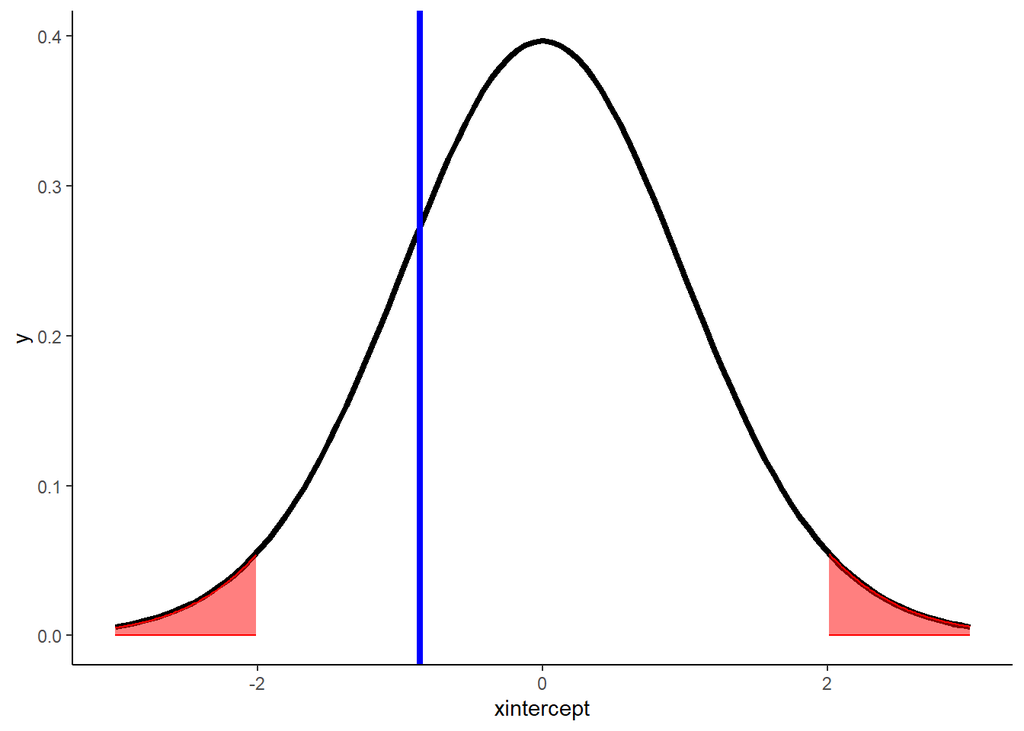

```r
base=ggplot() +
  xlim(-3, 3)

base +
  geom_function(fun = dt,args = list(df=48),linewidth=1.5)+
  stat_function(fun = dt,args = list(df=90), color = "red", fill = "red", geom = "area",xlim=c(-3, -2.010635), alpha = 0.5)+
  stat_function(fun = dt,args = list(df=48), color = "red", fill = "red", geom = "area",xlim=c(2.010635, 3), alpha = 0.5)+
  theme_classic()+
  geom_vline(xintercept = -0.859,linewidth=1.5,col='blue')
```

Assim, é possivel notar que o valor da estatistica do teste está dentro do intervalo calculado e portanto não rejeita-se $H_0$, a diferença entre as medias de 2 dos generos masculino e feminino em uma turma de probabilidade é $0$ com $5\%$ significancia

## Resolução computacional

```r
var.test(notas_fem_turma_g$TurmaGNotas,notas_masc_turma_g$TurmaGNotas)
```

```
##
##  F test to compare two variances
##
## data:  notas_fem_turma_g$TurmaGNotas and notas_masc_turma_g$TurmaGNotas
## F = 1.2936, num df = 16, denom df = 32, p-value = 0.5195
## alternative hypothesis: true ratio of variances is not equal to 1
## 95 percent confidence interval:
##  0.5754297 3.3027284
## sample estimates:
## ratio of variances
##           1.293574
```

```r
t.test(notas_fem_turma_g$TurmaGNotas,notas_masc_turma_g$TurmaGNotas,alternative = 'two.sided',paired=F,conf.level = .95,var.equal = T)
```

```
##
##  Two Sample t-test
##
## data:  notas_fem_turma_g$TurmaGNotas and notas_masc_turma_g$TurmaGNotas
## t = -0.85935, df = 48, p-value = 0.3944
## alternative hypothesis: true difference in means is not equal to 0
## 95 percent confidence interval:
##  -12.924263   5.184512
## sample estimates:
## mean of x mean of y
##  64.70588  68.57576
```